# Economía Política

Unidad 2. En la vida hay que elegir. ¿Cómo eligen las sociedades?

Sebastian Freille

Universidad Nacional de Córdoba

> Una mayoría sujeta a las limitaciones constitucionales y que cambie fácilmente conforme a los cambios de la opinión popular es el verdadero soberano de un pueblo libre; el que la deseche cae en la anarquía; la unanimidad es imposible; rechazando el principio de la mayoría, sólo queda ya el despotismo…  
> **[Abraham Lincoln, *Toma de Posesión* (1861)]**

# **El problema de (economía política) la política económica**

- Problema general de política
- Restricciones sobre preferencias individuales
- Violación de restricciones

## Introducción

- Elección de la política económica importa una decisión colectiva a partir de intereses (preferencias) individuales e instituciones políticas determinadas
- Decisiones difieren según instituciones políticas –dictadura versus democracia $\longrightarrow$ tanto en el proceso como en los resultados
- Existen dos modelos tipicos de democracia –directa y representativa. Si bien difieren en muchos aspectos, ambas tienen en el centro del proceso decisorio a mecanismos de votacion.

## Democracia directa

- Si bien la democracia directa no se usa como mecanismo principal, los países tienen herramientas de participación directa:
  - Referendum
  - Consulta popular, vinculante y no vinculante
  - Asambleas al aire libre
- Fuentes y bases de datos:
  - Base de datos de IDEA $\longrightarrow$ https://www.idea.int/data-tools/data/direct-democracy
  - Swissvotes $\longrightarrow$ https://swissvotes.ch/page/home

## Democracia directa (cont.)

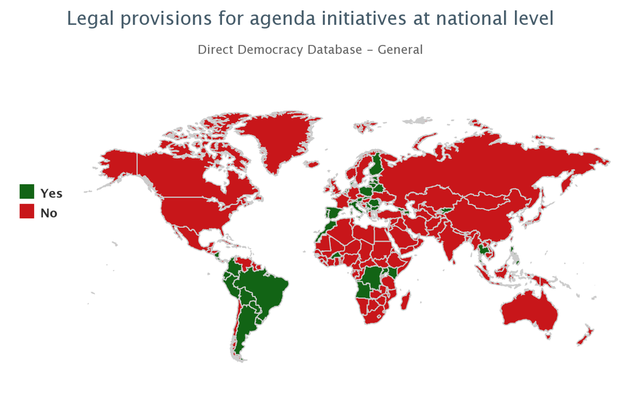

Provisiones legales para iniciativas de agenda en nivel nacional

## Democracia directa (cont.)

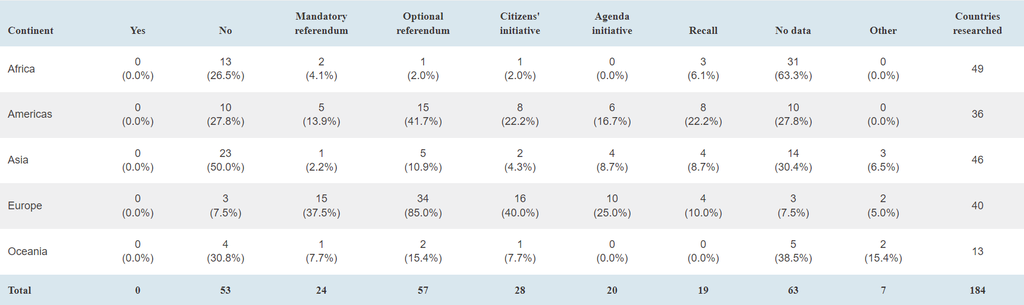

Provisiones legales para democracia directa en nivel local

## Problema general de política

- Un conjuto de ciudadanos –pequeño como en un comité, grande como un electorado-afectados por un vector de políticas **$q$**
- Los ciudadanos –*votantes*- están indexados a partir de atributos individuales. Entonces, $\alpha^{i}$ denota las características específicas del votante $i$ (preferencias idiosincráticas, dotaciones, riesgos, otros atributos socioeconómicos)
- Los $\alpha^{i}$’s se distribuyen entre los individuos de acuerdo a una distribución dada
- Los ciudadanos tienen funciones de utilidad sobre canastas de consumo $c^{i}$

## Problema general de política (cont.)

- Individuo como **agente económico** elige su canasta de consumo para maximizar su fn. de utilidad sujeto a restricciones (presupuestarias/tiempo):
  $$\begin{aligned}
  U(c^{i},\mathbf{q},\mathbf{p};\alpha^{i}) \\
  H(c^{i},\mathbf{q},\mathbf{p};\alpha^{i}) \geq 0
  \end{aligned}$$
- donde $\mathbf{p}$ es un vector de variables determinadas en el mercado (precios, cantidades). La fn. de utilidad indirecta de $i$ es:
  $$\begin{aligned}
  \tilde{W}(\mathbf{q},\mathbf{p};\alpha^{i})=\max_{c^{i}}[U(c^{i},\mathbf{q},\mathbf{p};\alpha^{i})\mid H(c^{i},\mathbf{q},\mathbf{p};\alpha^{i}) \geq 0]
  \end{aligned}$$

## Problema general de política (cont.)

- El gobierno como **policymaker** fija vector de políticas $\mathbf{q}$ bajo ciertas restricciones: respetar los valores de $\mathbf{p}$ dados en el mercado, presupuesto equilibrado, y otras. Así:
  $$\begin{aligned}
  G(\mathbf{q},\mathbf{p})\geq 0
  \end{aligned}$$
- Si las restricciones son vinculantes entonces, $\mathbf{p}=P(\mathbf{q})$ –esto es, los valores de mercado dependerán de $\mathbf{q}$ y de parámetros
- El individuo como **agente político** actúa como votante, lobista, y otras. Sus acciones están determinadas por sus *preferencias de política* –obtenidas de su fn. de utilidad indirecta, $\tilde{W}$.

## Problema general de política (cont.)

- Las preferencias de política de forma reducida son:
  $$\begin{aligned}
  \tilde{W}(\mathbf{q},P(\mathbf{q});\alpha^{i})
  \end{aligned}$$
- La política preferida, o**punto ideal**, del votante $i$ es:
  $$\begin{aligned}
  \mathbf{q(\alpha^{i})}=\arg\max_{q} W(\mathbf{q};\alpha^{i})
  \end{aligned}$$
- El **conflicto en las preferencias de política surge por las diferencias en $\alpha^{i}$**.

## Problema de política con 2 (dos) individuos

- Individuos maximizan una función de utilidad $U(x_{1},x_{2};\alpha^{i})$ –$x_{1}$ y $x_{2}$ bienes privados. El gobierno le saca $\tau$ del $Y$ al individuo y le devuelve $T$ como transferencia de suma fija
  $$p_{1}x_{1}+p_{2}x_{2} \leq (1-\tau)Y+T$$
- El problema consiste en maximizar la utilidad sujeta a la restricción presupuestaria $\longrightarrow$ se obtienen las demandas individuales $x_{1}(p_{1},p_{2},Y,\tau,T;\alpha^{i})$ y $x_{2}(p_{1},p_{2},Y,\tau,T;\alpha^{i})$
- El parámetro $\alpha$ en la función de utilidad captura la heterogeneidad de preferencias

## Problema de política con 2 (dos) individuos

- Reemplazando demanda en la fn. de utilidad, tenemos la fn. de utilidad indirecta:
  $$\begin{aligned}
  V(p_{1},p_{2},Y,,\tau,T;\alpha^{i}) \equiv \\
  U(x_{1}(p_{1},p_{2},Y,\tau,T;\alpha^{i}),x_{2}(p_{1},p_{2},Y,\tau,T;\alpha^{i});\alpha^{i})
  \end{aligned}$$
- Importante $\longrightarrow$ utilidad es función de las variables de política [dado que $x_{1}$ y $x_{2}$ son elegidos de manera óptima]
  $$\begin{aligned}
  V(\tau,T;\alpha^{i}) \equiv \\ V(p_{1}(\tau,T),p_{2}(\tau,T),Y(\tau,T),\tau,T;\alpha^{i})
  \end{aligned}$$

## Problema de política con 2 (dos) individuos

- Conociendo $\tau$ conocemos $T$ [¿por qué?] y la fn. UI:
  $$V(\tau;\alpha^{i})$$
- Política preferida por *i* se obtiene hallando $\tau$ que maximiza U indirecta:
  $$\frac{\partial V(\tau;\alpha^{i})}{\partial \tau}=0$$
- $\tau^{*}(\alpha^{i})$ $\longrightarrow$ dimensión política evidente –$\alpha^{i}$’s diferentes implican políticas (alícuotas) preferidas diferentes

## Ilustración y aplicación

- Evidencia sugiere que no hay diferencias significativas en el apoyo a mayor redistribución en EEUU de acuerdo a diferencias etarias, de etnia y género. Incluso hay dos grupos que han disminuido su apoyo a la redistribución: los adultos mayores y los afroamericanos. Sorprendemente son dos de los grupos más dependientes en transferencias desde el estado [Ashok, V., Kuziemko, I., & Washington, E. (2015)].
- Stantcheva (2021) estudia el apoyo a la redistribución usando experimentos sociales de gran escala (videos informativos) y estudia diferencias según género, etnia, nivel de ingreso e ideología/afiliación.

## Ilustración y aplicación (cont.).

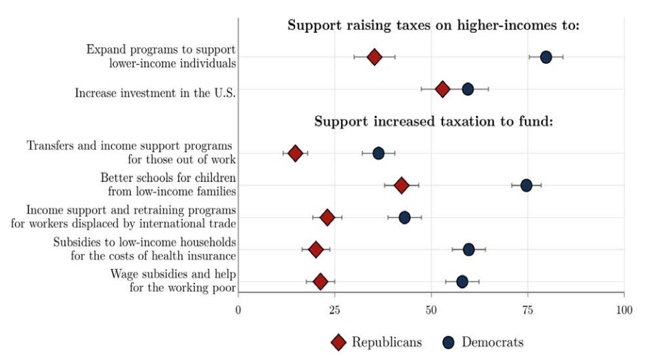

Grado de apoyo a redistribución - Ideología/Partidismo

## Ilustración y aplicación (cont.)

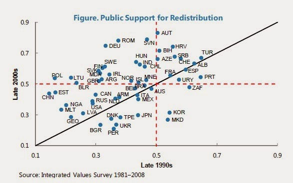

Grado de apoyo a redistribución - Evolución

## Ilustración y aplicación (cont.)

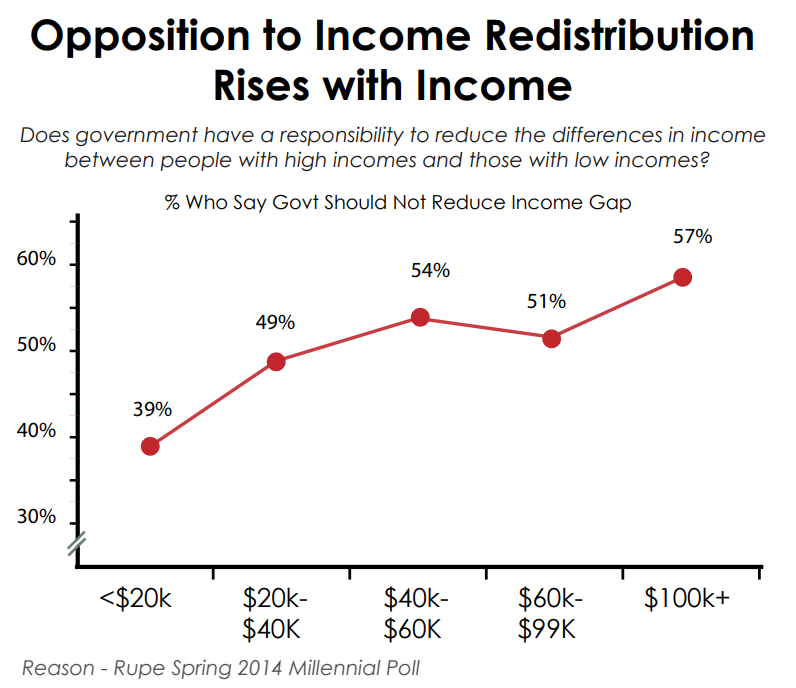

Grado de apoyo a redistribución de millenials - Edad e ingresos

# **Alternativas, preferencias y elección**

- Preferencias y propiedades
- Casos de 2 y más alternativas

## Preferencia y elección

- Sea un individuo, $i$, y 3 objetos –“alternativas”-, $A$, $B$, y $C$ sobre los que $i$ tiene preferencias
- El individuo $i$ es capaz de evaluar:
  - “Prefiero $A$ a $B$”
  - “Soy indiferente entre $B$ y $C$”.
- La relación $A \succ B$ representa al primer enunciado; la relación $B \sim C$ representa al segundo
- La **elección** de $i$ es racional si está de acuerdo con su **preferencia**. Sujetas a ciertas propiedades que permita “ordenarlas”

## Preferencia y elección (cont.)

- Sean $A$ y $B$ dos alternativas de política. Un individuo vota por $A$ siempre que $W(A) \geq W(B)$.
- Sea $\succeq_{i}$ una relacion binaria tal que $A \succ_{i} B$ significa que el individuo *i* prefiere a $A$ –$W(A) \geq W(B)$ y donde $\succeq_{i}$ cumple con las propiedades estándares de las preferencias
  - **Completas:** $A \preceq_{i} B$, o $B \preceq_{i} A$, o ambas – en este caso el individuo es indiferente
  - **Transitivas:** si $B \preceq_{i} A$ y $A \preceq_{i} C$, entonces $C \preceq_{i} A$
- Como puede verse las preferencias están dadas al nivel individual

## Ordenamiento de preferencias

- Si las preferencias de $i$ satisfacen estas propiedades, decimos que $i$ tiene un **ordenamiento de preferencias racional**. La elección racional será la que esté al inicio (izquierda) del ordenamiento
- No todas las relaciones entre “alternativas” son **completas** o **transitivas**. Ejemplos:
  - La comparación debe tener sentido $\longrightarrow$ elegir entre cosas desconocidas (comparabilidad)
  - La comparación debe ser sobre algo que le importa al individuo

## Caso: Dos alternativas

- Condiciones deseadas de un sistema de reglas de votación entre dos alternativas:
  - **Anonimidad** $\longrightarrow$ si 2 votantes intercambian sus votos antes de emitirlos, el resultado de la elección no cambia (votantes simétricos)
  - **Neutralidad** $\longrightarrow$ si cada votante revierte su orden de preferencia –i.e si votó A, ahora vota B y viceversa-, el resultado de la elección se revierte (alternativas simétricas)
  - **Monotonicidad** $\longrightarrow$ si un votante único que originalmente votó por el perdedor elección, ahora vota por el ganador, el ganador de la elección sigue siendo el mismo.

## Caso: Dos alternativas (cont.)

- Siempre que el número de votantes sea impar, habrá un resultado cierto. Si se vota por regla de mayoría absoluta, se elegirá la opción preferida por una mayoría de votantes, i.e. $\frac{N+1}{2}$

**Teorema de May**

El único método que satisface las condiciones de anonimidad, neutralidad y monotonicidad para determinar un ganador de una elección entre dos alternativas es la regla de la mayoría absoluta.

## Argentina:

[figure not shown]

No trates de entenderla…

## Caso: Dos alternativas (cont.)

- $A \succ_{1} B$
- $A \succ_{2} B$
- $B \succ_{3} A$

> El ganador es $A$. ¿Que pasa si intercambian sus votos? (anonimidad)
- $A \succ_{1} B$
- $B \succ_{3} A$
- $A \succ_{2} B$

> ¿Que pasa si cada uno revierte su preferencia? (neutralidad)
- $B \succ_{1} A$
- $B \succ_{2}A$
- $A \succ_{3} B$

> Qué pasa si votó antes por el perdedor, ahora vota por el ganador? (monotonicidad)
- $A \succ_{1} B$
- $A \succ_{2} B$
- $A \succ_{3} B$

## Caso: 3 o más alternativas

- ¿Qué sucede si, como en situaciones de la vida real hay más de 2 alternativas?
- El problema se vuelve más complejo. Problema $\longrightarrow$ existe alguna regla de votación que permita agregar preferencias individuales en preferencias sociales y que produzca un claro ganador y que satisfaga propiedades deseadas?
  - La respuesta es **no**.

## Caso: 3 o más alternativas (cont.)

| Orden | Juan | Pedro | María |
| --- | --- | --- | --- |
| 1 | A | C | B |
| 2 | B | A | C |
| 3 | C | B | A |

- ¿Hay ganador por mayoría absoluta? No. Ninguna tiene la mitad mas uno de los votos (2). ¿Hay ganador por mayoría simple (pluralidad)? No. Ninguna alternativa tiene más votos que otra –ie. hay triple empate.

## Caso: 3 o más alternativas (cont.)

**Teorema de la imposibilidad de Arrow**

No existe una función de ordenamiento social $\succ$ tal que para cualquier grupo G cuyos miembros tengan todos preferencias racionales, $\succ$ sea un ordenamiento racional (transitivo) y que satisfaga los cuatros supuestos de dominio universal, optimalidad de Pareto, independencia de alternativas irrelevantes y no dictadura.

- Si queremos una función de ordenamiento social que cumpla con todas esas propiedades, no será transitiva $\longrightarrow$ habrá ciclos.

# **Resolviendo el problema**

- El teorema de la imposibilidad
- Restringiendo preferencias e instituciones
- Políticas unidimensionales vs multidimensionales
- Aplicación: Redistribución con imposición

## Resolviendo el problema

> Un tratamiento positivo del problema general de política económica involucra especificar un diseño institucional específico y preguntarse como el mismo agrega las acciones políticas, basadas en las preferencias de política individuales, en políticas de equilibrio.

… pero …

## Pasaron cosas…

[figure not shown]

El Teorema de la Imposibilidad dice que no

## Restricciones y supuestos

- Aún la **regla de mayoría** utilizada extensivamente en elecciones alrededor del mundo no es suficiente para producir políticas de equilibrio bien definidas
- Para producir estas políticas de equilibrio bien definidas, se deben suponer/restringir una de dos cosas:
  1. Las preferencias de política individuales a ciertas formas
  2. Las instituciones políticas a ciertos tipos

## Agregación de preferencias

- Agregación de preferencias bajo **regla de mayoría pura**, definida como:
  1. **Democracia directa** $\longrightarrow$ los ciudadanos eligen *directamente* las alternativas
  2. **Voto sincero** $\longrightarrow$ en toda votación, cada ciudadano *vota* por la alternativa que le da la mayor utilidad de acuerdo a sus preferencias de política (fn. de utilidad indirecta), $W(\mathbf{q};\alpha^{i})$.
  3. **Agenda abierta** $\longrightarrow$ cada ciudadano vota entre pares de alternativas en sucesivas rondas –votación Condorcet (*pairwise voting*, en inglés)

## Teorema del jurado y la paradoja de Condorcet

> **Marie-Jean-Antoine-Nicolas de Caritat, marquis de Condorcet.** Filósofo y matemático francés. Fue un precursor de los derechos humanos, el reclamo de justicia, las ideas democráticas y de los derechos de las mujeres. Durante su vida combinó el pensamiento analítico y formal con sus acciones e ideas políticas –pasó de apoyar una monarquía constitucional a una república democrática y de apoyar el voto calificado (según bienes) al voto uniersal. Murió en la cárcel luego de huir durante años de las autoridades de la Revolución Francesa. Dejó dos ideas memorables para la ciencia y economía política: 1) la paradoja de Condorcet; 2) el teorema del jurado.

## Teorema del jurado y la paradoja de Condorcet (cont.)

**Teorema del jurado y la paradoja de Condorcet (cont.)**

Dado un grupo de votantes (“un jurado”) decidiendo independientemente entre un resultado correcto con *$prob$* $0 \leq 1$ y un resultado incorrecto con *$prob$* $1-p$. 1. Si $p > 1/2$ (c/votante tiende a votar más correcto que incorrecto), añadir más votantes aumenta la *$prob$* de que la mayoría elija correctamente y la *$prob$* de una decisión correcta tiende a 1 2. Si $p < 1/2$ (c/votante tiende a votar más incorrecto que correcto), añadir más votantes disminuye la *$prob$* de que la mayoría elija correctamente y la *$prob$* de una decisión correcta se maximiza para un tamaño igual a 1.

- Link: [Teorema del jurado](https://www.geogebra.org/m/ntctceas)

## Preferencias de pico único

**Definición 1**

Un **ganador de Condorcet** es una política $\mathbf{q^{*}}$ tal que vence a cualquier otra política factible en una votación de a pares

- Sea un espacio de política unidimensional de modo que $q$ es un escalar. Según Black (1948), las preferencias de políticas
  $$\begin{aligned}
  \mathbf{q(\alpha^{i})}=\arg\max_{q} W(\mathbf{q};\alpha^{i})
  \end{aligned}$$
- son de *pico único* para $i$ si su ord. de pref. se rige por la distancia a su punto ideal, $q(\alpha^{i})$: una política más cercana a $q(\alpha^{i})$ es preferida a una(s) mas lejana(s).

## Preferencias de pico único (cont.)

**Definición 2**

Las preferencias de política del votante $i$ son **de pico único** si lo siguiente se cumple:  
Si $q^{''} \leq q^{'} \leq q(\alpha^{i})$ o $q^{''} \geq q^{'} \geq q(\alpha^{i})$, entonces  
$W(q^{''};\alpha^{i}) \leq W(q^{'};\alpha^{i})$

- Un primer resultado simple pero útil es:

**Proposición 1**

Si todos los votantes tienen preferencias de política de pico único sobre un ordenamiento dado de alternativas de política, un ganador de Condorcet siempre existe y coincide con el punto ideal del mediano

## Preferencias de pico único (cont.)

- Considere 3 (tres) individuos que difieren sólo en sus niveles de ingreso (y eso moldea sus prefs. por políticas). El individuo 1 es de $Y$ alto (prefiere $T$ bajos), el individuo 2 es de $Y$ medio y prefiere $T$ medianos y el individuo 3 es de $Y$ bajo y prefiere $T$ altos.
- Si $A$, $B$ y $C$ son tasas bajas, medias y altas respectivamente entonces:
  $$\begin{aligned}
  \tau^{*}(\alpha^{1})=A \\
  \tau^{*}(\alpha^{2})=B \\
  \tau^{*}(\alpha^{3})=C \\
  \end{aligned}$$
- En base a la figura, exprese el orden de preferencias de cada individuo. ¿Qué nota?

## Preferencias de pico único (cont.)

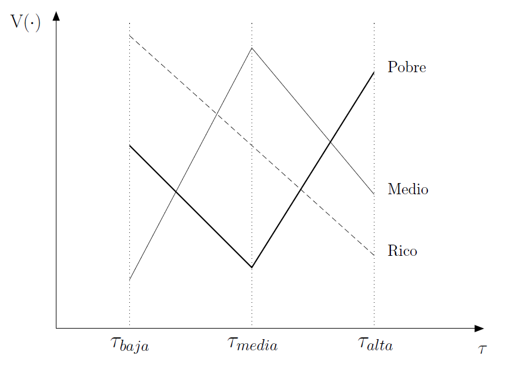

Preferencias de política ($\tau$) [Fuente: Fergusson y Querubin (2018)]

## Políticas unidimensionales (cont.)

*Fijamos el vector de parámetros a un valor dado, ordenamos a los individuos en función de sus puntos ideales $q(\alpha^{i})$ y etiquetamos al punto ideal del mediano como $q^{m}$. Suponga que $q^{m}$ se enfrenta en votación de a pares a cualquier otra política $q^{''}<q^{m}$. De acuerdo a la Definición 2, cualquier individuo cuyo punto ideal satisface $q^{m} \leq q(\alpha^{i})$ prefiere $q^{m}$ a $q^{''}$ dado que está más cerca de su punto ideal. Por el supuesto de voto sincero (A2), votan por $q^{m}$. La coalición que vota por $q^{m}$ entonces constituye una mayoría. Por razonamiento análogo a $q^{''}>q^{m}$, obtenemos el resultado de que $q^{m}$ es un ganador de Condorcet*

## El votante mediano

**Corolario 1**

$q^{m}$ es la única política de equilibrio (punto estable) bajo regla de mayoría pura, esto es bajo supuestos A1-A3.

- La intuición es sencilla: $q^{m}$ vence a cualquier otro ganador previo apenas se presenta y no puede luego ser vencida en ninguna votación de a pares sucesiva
- Hay dos supuestos bastante fuertes detrás de este resultado: 1) unidimensionalidad; 2) preferencias de pico único.

## El votante mediano (cont.)

[figure not shown]

El votante mediano no existe!

## Aplicación: Preferencias s/aborto

- Cuestión del aborto en EEUU $\longrightarrow$ polarización
  - Provida (V) $\longrightarrow$ prohibir aborto totalmente; Proeleccion (E) $\longrightarrow$ derecho absoluto a elegir; Roe-Wade (R) $\longrightarrow$ aborto en etapa temprana. ¿Cuáles son las preferencias?
    - $V \succ_{v} R \succ_{v} E$ (provida)
    - $E \succ_{e} R \succ_{e} V$ (proeleccion)
    - $R \succ_{rw1} V \succ_{rw1} E$ (roe-wade1)
    - $R \succ_{rw2} E \succ_{rw2} V$ (roe-wade2)
- Ninguno de los grupos considera a $R$ como la peor alternativa $\longrightarrow$ ¿consenso?

## Aplicación: Preferencias s/aborto (cont.)

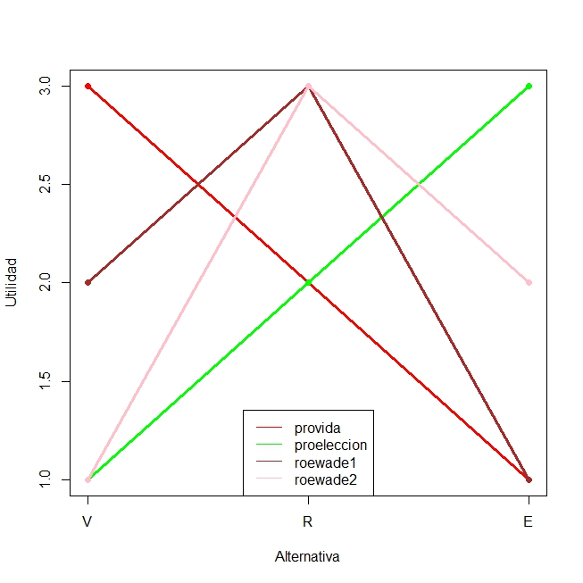

Polarización y preferencias de pico único

## Aplicación: Preferencias s/aborto (cont.)

> **Implicancia fundamental** $\longrightarrow$ aún cuando los miembros del grupo tengan puntos de vista **muy diferentes** sobre lo que el grupo debería hacer, la **regla de la mayoría funciona a la perfección** siempre y cuando se obtenga un grado mínimo de consenso (captado mediante una curva de pico único).

## Limitaciones y realismo

- El supuesto de unidimensionalidad de $q$ restringe fuertemente el menú de instrumentos de política –piense en un combo de PF y PM.
- El supuesto de preferencias de pico único es satisfecho cuando los agentes no hacen elecciones económicas. Pero los problemas interesantes surgen cuando hay elecciones económicas endógenas (a los instrumentos de pólitica)
  - Problema $\longrightarrow$ rdo. del mercado depende de la política y a su vez entran en las preferencias de política individuales (externalidades, indivisibilidades, etc). En el modelo: $P(q)$ como argumento de $W$.

## Propiedad de cruce único

- Variante más general $\longrightarrow$ propiedad de cruce único (*single-crossing property*). La restricción no es sobre la forma de las preferencias individuales sino sobre la forma de la heterogeneidad en votantes. Supone unidimensionalidad no sólo en $q$ sino también en $\alpha^{i}$ con dominio en el intervalo $\mathcal{V}$ (el conjunto de votantes).

**Definición 3**

Las preferencias de los votantes en $\mathcal{V}$ satisfacen la **propiedad de cruce único** si lo siguiente se cumple:  
Si $q>q^{'}$ y $\alpha^{i'}>\alpha^{i}$, o si $q<q^{'}$ y $\alpha^{i'}<\alpha^{i}$, entonces  
$W(q;\alpha^{i}) \geq W(q^{'};\alpha^{i})$ $\Rightarrow$ $W(q;\alpha^{i'}) \geq W(q^{'};\alpha^{i'})$

## Propiedad de cruce único (cont.)

**Proposición 2**

Si las preferencias de los votantes en $\mathcal{V}$ satisfacen la propiedad de cruce único, un ganador de Condorcet siempre existe y coincide con el punto ideal del votante con el valor mediano de $\alpha^{i}$.

- La propiedad de cruce único es similar a de pico único $\longrightarrow$ proyecta las preferencias por $q$ sobre el conjunto de tipos de votantes $\mathcal{V}$.
- Intuición $\longrightarrow$ dadas dos políticas cualesquiera, una más a la derecha que la otra, mientras más “de derecha” sea un individuo (con relación a otro individuo), más preferirá la política de la derecha a la de la izquierda.

## Propiedad de cruce único (cont.)

- Para probar esta proposición, etiquete al valor crítico de $\alpha^{i}$ como $\alpha^{m}$. Entonces, por Definición 3, cualquier votante con $\alpha^{i} \geq \alpha^{m}$ prefiere $q(\alpha^{m})$ a cualquier $q < q(\alpha^{m})$. En forma similar, cualquier votante con $\alpha^{i} \leq \alpha^{m}$ prefiere $q > q(\alpha^{m})$. En otras palabras, $q(\alpha^{m})$ gana un voto de a pares ante cualquier otra alternativa posible*

## Propiedad de cruce único (cont.)

> En cuestiones políticas y electorales, la propiedad de cruce único puede ser más realista e intuitiva que la propiedad de pico único. Si los diferentes *tipos* son interpretados como diferentes tipos ideológicos ordenados en una escala de izquierda a derecha, y luego las alternativas son políticas públicas a ser elegidas por la sociedad. De esta forma, dadas 2 (dos) políticas, una más a la derecha que la otra, mientras mas *“derechoso”* sea el tipo, más preferirá la política que está más a la derecha por sobre la que está a la izquierda.

## Propiedad de cruce único (cont.)

- Note las diferencias con *preferencias de pico único* $\longrightarrow$ intuitivamente un perfil de preferencias de pico único es uno en que el conjunto de alternativas pueden ordenarse a lo largo de un eje izquierda-derecha de modo que cada individuo tenga un punto ideal único y el ordenamiento individual de las otras alternativas cae hacia (ambos) costados del punto ideal
- Con las *preferencias de cruce único* no ordenamos las alternativas sino que ordenamos a los individuos y en definitiva lo que se supone es que hay un mapeo de individuos a alternativas

## Comparando ambas

- ¿Más realista? $\longrightarrow$ más natural y razonable *ordenar a las personas* en base a un único parámetro (ingreso, productividad, ideología) que *ordenar a las alternativas*.
- El conflicto de interés surge a partir de la distribución de *tipos* de individuos distribuidos a lo largo de un espacio unidimensional
- Resumiendo:
  1. Preferencias de pico único $\longrightarrow$ puntos ideales medianos
  2. Propiedad de cruce único $\longrightarrow$ puntos ideales del agente de tipo mediano

# **Ejemplos y aplicaciones**

- Ejemplos de PPU y PCU
- Aplicaciones del teorema del votante mediano
  - Redistribución simple
  - Heterogeidad en preferencias por bien público
  - Redistribución con imposición distorsiva (PCU)

## Ejemplo

$$\begin{aligned}
x \succ_{1} y \succ_{1} z \\
x \succ_{2} z \succ_{2} y \\
z \succ_{3} y \succ_{3} x
\end{aligned}$$

- Pueden no ser PPU y si PCU. El ordenamiento natural es $x<y<z$ y sea:

$$\begin{aligned}
z \succ_{2} y \Rightarrow z \succ_{3} y\\
x \succ_{2} z \Rightarrow x \succ_{1} z\\
x \succ_{2} y \Rightarrow x \succ_{1} y
\end{aligned}$$

## Ejemplo (cont.)

- Pueden si ser de pico único y no de cruce único…
  $$\begin{aligned}
  w \succ_{1} x \succ_{1} y \succ_{1} z \\
  x \succ_{2} y \succ_{2} z \succ_{2} w \\
  y \succ_{3} x \succ_{3} w \succ_{3} z
  \end{aligned}$$
- No satisfacen la propiedad de cruce único. El ordenamiento natural es $w<x<y<z$ y si $2<3$, $z \succ_{2} w$ pero $z \succ_{3} w$; para $3<2$, $y \succ_{3} x$ pero $y \succ_{2} x$.

## Ejemplo (cont.)

- Considere el siguiente perfil de preferencias:
  $$\begin{aligned}
  1 \succ_{1} 2 \succ_{1} 3 \succ_{1} 4 \\
  2 \succ_{2} 3 \succ_{2} 1 \succ_{2} 4 \\
  3 \succ_{3} 2 \sim_{3} 4 \succ_{3} 1 \\
  4 \succ_{4} 3 \succ_{4} 2 \succ_{4} 1
  \end{aligned}$$

## Ejemplo (cont.)

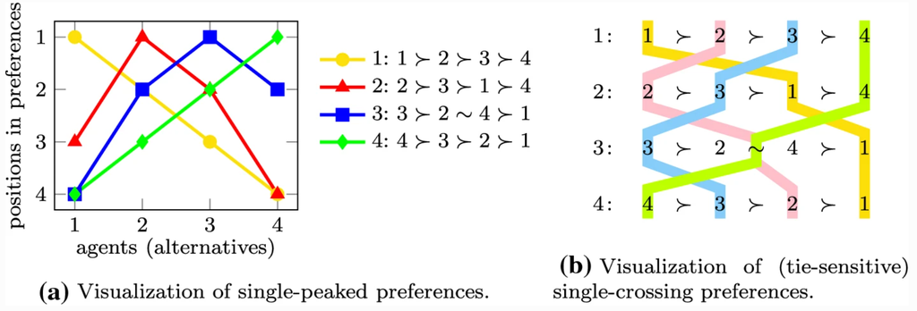

Pico único versus cruce único

## Aplicación: Modelo simple de redistribución

- Hay $\delta$ individuos ricos y $(1-\delta)$ individuos pobres con $\delta < \frac{1}{2}$. Pobres tienen ingresos (exógenos) $y^{p}$ y ricos $y^{r}$
- Ingreso total $\longrightarrow$ $\delta y^{r}+(1-\delta)y^{p}=y$ –población normalizada a $1$ por lo que $y=\bar{y}$. Sea $\theta$ fracción de $y$ en manos de ricos tal que $y^{r}=\frac{\theta y}{\delta}$ y que $y^{p}=\frac{(1-\theta)y}{1-\delta}$
- Note que $y^{r} > y^{p}$ y que $\theta > \delta$. Aumento en $\theta$ es más desigualdad, si $\theta=\delta$, hay perfecta equidad
  $$\begin{aligned}
  c^{i}=(1-\tau)y^{i}+T \\
  T=\tau(\delta y^{r}+(1-\delta)y^{p})=\tau y
  \end{aligned}$$

## Aplicación: Modelo simple de redistribución (cont.)

- Utilidad lineal en el consumo, $u=c^{i}$. Sustituyendo RP del gobierno, la $V$ es:
  $$\begin{aligned}
  V^{i}(\tau)=(1-\tau)y^{i}+\tau y
  \end{aligned}$$
- Y la politica preferida maximiza $V^{i}(\tau)$ por lo que:
  $$\begin{aligned}
  \frac{\partial V^{i}(\tau)}{\partial \tau}=-y^{i}+y
  \end{aligned}$$
- Pobres $\longrightarrow$ prefieren $\tau=1$ ($y$ menor al promedio); ricos $\longrightarrow$ prefieren $\tau=0$. Según el TVM $\longrightarrow$ $\tau^{eq}=1$ [¿Por qué?]

## Aplicación: Modelo simple de redistribución (cont.)

- Mas realismo $\longrightarrow$ hay costo asociado a la imposición (DWL) por lo que pobres no eligen $\tau=1$. Ahora:
  $$\begin{aligned}
  T=\tau y - c(\tau)y
  \end{aligned}$$
- donde $c'(\tau)>0$, $c''(\tau)>0$, $c'(0)=0$, y $c'(1)=\infty$. Con lo que la nueva $V(.)$ es
  $$\begin{aligned}
  V^{i}(\tau)=(1-\tau)y^{i}+T=(1-\tau)y^{i} +\tau y - c(\tau)y
  \end{aligned}$$
- CPO es $c'(\tau^{eq})y=y-y^{i}$. De modo que ahora en $\tau=1$, $c'(\tau)=\infty$, y *cualquier individuo* mejora utilidad con baja de T.

## Aplicación: Modelo simple de redistribución (cont.)

- Para verificar preferencias unimodales, tomamos 2da derivada de V: $-c''(\tau)<0$. Sustituyendo $y^{p}=\frac{(1-\theta)y}{1-\delta}$ en CPO:
  $$\begin{aligned}
  c'(\tau^{p})=\frac{\theta-\delta}{1-\delta}
  \end{aligned}$$
- Si $\theta$ sube, $\tau^{p}$ aumenta –interprete [Meltzer and Richard (1981)]. Implicancias:
  - Mayor desigualdad, menor crecimiento [Persson and Tabellini (1994), Alesina and Rodrik (1994)]
  - ¿Por qué entonces los pobres votan? Los ricos tendrían incentivos a que no [Acemoglu and Robinson (2000)]

## Aplicación: valoración de BPP

- Individuo $i$ tiene preferencias sobre un bien privado $c^{i}$ y un bien público $g$ tales:
  $$\begin{aligned}
  u^{i}=c^{i}+\alpha^{i}H(g)
  \end{aligned}$$
- $H(.)$ es cóncava y $\alpha^{i}$ es parámetro intrínseco de agente con distribución acumulativa $F(\alpha)$ y función de densidad $f(\alpha)$. Normalizamos población a $1$ y todos los individuos tienen ingreso exógeno igual a $1$. Gobierno cobra $\tau$ a cada individuo y las RP son:
  $$\begin{aligned}
  c^{i}=1-\tau \\
  \tau=g
  \end{aligned}$$

## Aplicación: valoración de BPP (cont.)

- Maximizamos la UI de cada individuo $V^{i}(g)$ para encontrar el nivel preferido de $g$:
  $$\begin{aligned}
  \max_{\tau} V^{i}(g)=(1-g)+\alpha^{i}H(g)
  \end{aligned}$$
- De la CPO, el $g$ óptimo para $i$ satisface $\alpha^{i}H'(g)^{i}=1$
- Podemos usar TVM (fn utilidad cóncava y unidimensional). En este caso, hay una relación monótona entre $g^{i}$ y $\alpha^{i}$:
  $$\begin{aligned}
  \frac{\partial g^{i}}{\partial \alpha^{i}}=-\frac{H'(g^{i})}{\alpha^{i}H''(g^{i})}>0
  \end{aligned}$$
- Los que más valoran el BPP prefieren mayores niveles de gasto
- Individuo con $g^{i}$ mediano es también el individuo con $\alpha{i}$ mediano. Equilibrio político conduce al gasto que satisface:
  $$\begin{aligned}
  \alpha_{M}H'(g_{M})=1
  \end{aligned}$$
- donde $F(\alpha_{M})=1/2$

## Aplicación: valoración de BPP (cont.)

- Provisión política del bien bajo democracia directa *en general ineficiente*:
  $$\begin{aligned}
  \max_{g} (1-g)+H(g) \int \alpha^{i})f(\alpha^{i})d\alpha^{i}
  \end{aligned}$$
- Note que $\int \alpha^{i}f(\alpha^{i})d\alpha^{i}$ es la valoración media del BPP. LLamandole a $\alpha^{i}$ con $\bar{\alpha}$:
  $$\begin{aligned}
  \bar{\alpha}H'(g^{SO})=1
  \end{aligned}$$
- por lo que $g^{SO}$ y $g_{M}$ son distintos [sólo coinciden cuando distribución de $\alpha^{i}$ es tal que $\alpha_{M}=\bar{A}$]

## *Aplicación: Imposición distorsiva*

- Versión simplificada de modelos de Romer (1975), Roberts (1977) y Meltzer and Richard (1981). El individuo $i^{th}$ tiene preferencias cuasi-lineales
  $$\begin{aligned}
  w^{i}=c^{i}+V(x^{i})
  \end{aligned}$$
- donde $c^{i}$ y $x^{i}$ denotan consumo individual y ocio, respectivamente; y $V(.)$ es un función de utilidad cóncava. La RP privada es:
  $$\begin{aligned}
  c^{i} \leq (1-q)l^{i}+f
  \end{aligned}$$
- $q$ es alícuota del impuesto al $Y$, $l^{i}$ es O trabajo y $f$ es TSF

## *Aplicación: Imposición distorsiva (cont.)*

- El salario real es normalizado e igual a uno. La productividad individual difiere ($\alpha^{i}$) –ie. diferencias en la cantidad de *tiempo efectivo* disponible
  $$\begin{aligned}
  1-\alpha^{i} \geq x^{i}+l^{i}
  \end{aligned}$$
- $\alpha^{i}$ se distribuye con media $\alpha$ y mediana $\alpha^{m}$. La oferta de trabajo óptima es:
  $$\begin{aligned}
  l^{i}=L(q)-(\alpha^{i}-\alpha)
  \end{aligned}$$
- donde $L(q) \equiv 1-\alpha-V_{x}^{-1}(1-q)$ es decreciente en $q$ por concavidad de $V(.)$

## *Aplicación: Imposición distorsiva (cont.)*

- Los consumidores más productivos trabajan *más a cada alícuota*. Sea $l$ la oferta de trabajo media y como la media de $\alpha^{i}$ es $\alpha$, entonces $l=L(q). Por lo que la RP del gobierno es:$$\begin{aligned} f \leq ql \equiv qL(q) \end{aligned}$$
- Sea $q$ la variable de política($f$ determinada como residuo) y sustituyendo en la fn. de utilidad individual:
  $$\begin{aligned}
  W^{i}(q;\alpha^{i}) \equiv L(q)+V(1-L(q)-\alpha)-(1-q)(\alpha^{i}-\alpha)
  \end{aligned}$$

## *Aplicación: Imposición distorsiva (cont.)*

# **Reglas de votación**

- Diferentes reglas de votación
- Votación con ciclos: frecuencia y casos
- Problemas y limitaciones del análisis
- Intuición gráfica del TVM

## Votación Condorcet

- Suponga que un colectivo debe elegir entre 3 alternativas: A, B y C. Hay a priori 6 formas diferentes en que las preferencias pueden ser ordenadas:
  - $A \succ_{1} B \succ_{1} C$
  - $A \succ_{2} C \succ_{2} B$
  - $B \succ_{3} A \succ_{3} C$
  - $B \succ_{4} C \succ_{4} A$
  - $C \succ_{5} A \succ_{5} B$
  - $C \succ_{6} B \succ_{6} A$

## Votación Condorcet (cont.)

- $A \succ_{1} B \succ_{1} C$
- $B \succ_{4} C \succ_{4} A$
- $C \succ_{6} B \succ_{6} A$
- Imagine ahora que se vota de a pares.
  - Voto entre A y B. ¿Quién gana? B
  - Voto entre B y C. ¿Quién gana? B
  - Voto entre C y A (¿es relevante?)
- ¿Hay alguna que gana a todas las demás? Si. La alternativa B. [¿Por qué A no puede ser un GdC? ¿Por qué C no es un GdC?]. La alternativa B es un **ganador de Condorcet**

## Votación Condorcet (cont.)

- $A \succ_{1} B \succ_{1} C$
- $B \succ_{4} C \succ_{4} A$
- $C \succ_{5} A \succ_{5} B$
- Imagine ahora que se vota de a pares.
  - Voto entre A y B. ¿Quién gana? A
  - Voto entre B y C. ¿Quién gana? B
  - Voto entre C y A. ¿Quién gana? C
- ¿Cuál debería ganar si hay transitividad? A
- No hay transitividad: **ciclo de Condorcet**
  $$A \succ B \succ C \succ A$$

## Ilustración: Fijar agenda

- Supongamos que tenemos 30 personas cuyas preferencias por 4 (cuatro) alternativas se distribuyen de la siguiente manera:

| votantes | preferencias |
| --- | --- |
| 10 | $A \succ D \succ C \succ B$ |
| 10 | $B \succ A \succ D \succ C$ |
| 10 | $C \succ B \succ A \succ D$ |

- ¿Puede $D$ ganar democráticamente? Si, manipulando el orden de votación como la siguiente: 1) Voto entre $B$ y $A$; 2) Voto entre $B$ y $C$; 3) Voto entre $C$ y $D$ $\longrightarrow$ todos disconformes con el resultado [¿Por qué?]

## Votación cíclica y agenda

- Recordando las preferencias que generaron un ciclo de Condorcet. Sea el orden de votación::
  - 1ra: A vs B. 2da: ganador de A vs B contra C
    - Dado que $A \succ B$ y $C \succ A$, gana C
  - 1ra: A vs C. 2da: ganador de A vs C contra B
    - Dado que $C \succ A$ y $B \succ C$, gana B
  - 1ra: B vs C. 2da: ganador de B vs C contra A
    - Dado que $B \succ C$ y $A \succ B$, gana A.
- El ganador depende depende del orden de votación! $\longrightarrow$ problema de los ciclos

## Ciclos con alternativas no definidas

- Suponga que tres legisladores deben elegir como distribuir un presupuesto de 1000 pesos entre tres provincias
  - Inicial $\longrightarrow$ $(333.3,333.3,333.3)$
  - Propuesta de 1 $\longrightarrow$ $(600,400,0)$ [gana por mayoría]
  - Propuesta de 3 $\longrightarrow$ $(0,600,400)$ [gana por mayoría]
  - Propuesta de 1 $\longrightarrow$ $(300,700,0)$ [gana por mayoría]
  - Propuesta de 3 $\longrightarrow$ $(333.3,333.3,333.3)$ y así…
- Este problema es conocido como el de **dividir un dólar** y muestra como existen ciclos $\longrightarrow$ alternativas no definidas

## Ciclos con alternativas definidas

- Sea un problema redistributivo similar pero con alternativas fijas, $x$, $y$, $z$. Eje vertical, cantidad de recursos de B; eje horizontal, cantidad de recursos de A, y el resto es para C. Líneas son las CI de cada político. Votación:
  - $y$ contra $z$, gana $y$
  - $y$ contra $x$, gana $x$
  - $x$ contra $z$, gana $z$
- Posible ciclo infinito aún con nro limitado de alternativas –respetando supuestos básicos

## Ciclos con alternativas definidas (cont.)

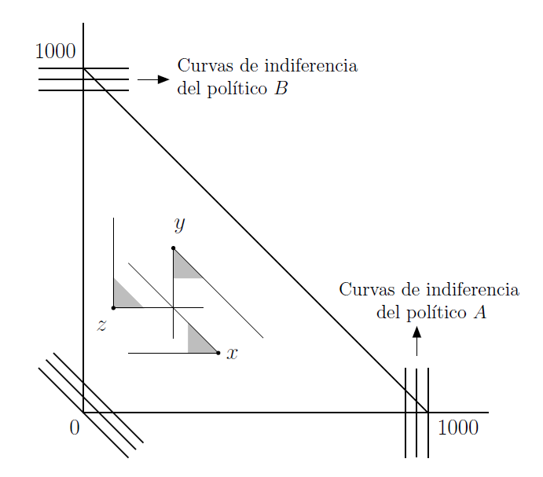

Ciclos e indeterminaciones

## Ocurrencia de ciclos

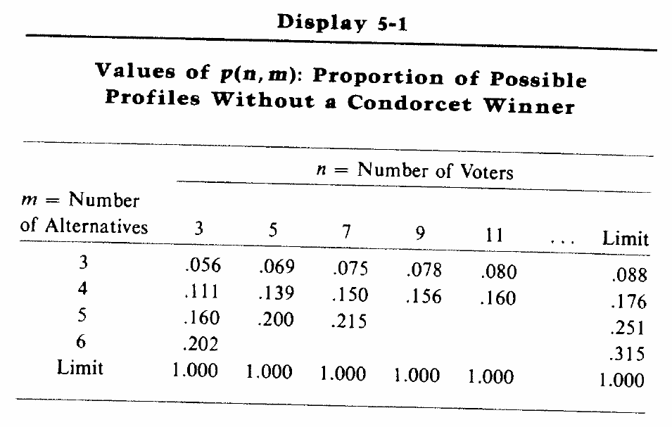

Perfiles de preferencias sin ganador de Condorcet

## Limitando ciclos: agenda cerrada

- Una forma es limitar número de rondas. Garantiza una política pero no sabemos cuál! Manipular agenda $\longrightarrow$ otorga poder a quien la controla ya que puede elegir su política preferida (*votación sincera*). Pero hay incentivos a votar estratégicamente
  - $B$ vota por $z$ en ronda 1 y obtiene $y$ en ronda 2 pero…
  - $A$ y $C$ también querrán ser estrategicos
    - equilibrios múltiples surgen facilmente
- ¿Votación sincera realista?
  - Si, cuando hay 2 alternativas
  - Si, cuando hay muchos votantes y ninguno es decisivo

## Poder de agenda

- Este simple ejemplo ilustra la importancia del “poder de agenda” –qué alternativas considerar y en qué orden las votamos.
- ¿Quiénes establecen la agenda en la vida real?
  - En el Congreso, el Presidente de la Cámara y los Presidentes de Comisión tienen amplios poderes para decidir que asuntos se giran y para proponer el orden de votaciones en el recinto. En EEUU, es el Speaker of the House
  - En regímenes presidencialistas, los ejecutivos también tienen poder de agenda (DNU, vetos, poderes delegados)
- El poder de agenda no es ilimitado ni da control absoluto, pero da alguna ventaja

## Votación Borda

- El **método de Borda** es una alternativa a Condorcet para superar el problema de los ciclos. Sean 5 votantes y 3 alternativas tal que:

| Orden | 1 | 2 | 3 | 4 | 5 |
| --- | --- | --- | --- | --- | --- |
| 1 | A | A | A | B | B |
| 2 | B | B | B | C | C |
| 3 | C | C | C | A | A |

- Cada individuo (grupo de individuos) van a puntuar las alternativas según el lugar (orden) que ocupen en el ordenamiento. A diferencia de Condorcet, este método usa toda la información de preferencias (intensidad de las preferencias).

## Votación Borda (cont.)

- Existen dos implementaciones alternativas del método de Borda:
  - La alternativa en 1er lugar recibe $n$ puntos, la alternativa en 2do lugar, recibe $n-1$ puntos, y así hasta la última alternativa donde “n” es el número de alternativas.
  - La alternativa en primer lugar recibe $n-1$ puntos, la alternativa en segundo lugar, recibe $n-2$ puntos, y así hasta la última donde “n” es el número de alternativas.
  - Pueden utilizarse ambos criterios a menos que esté explícitamente indicado un criterio en el ejercicio y/o práctico.

## Votación Borda (cont.)

- En este caso (solucionando por método “n-1”, las alternativas recibirían:
  - $A$ $\longrightarrow$ 6 votos
  - $B$ $\longrightarrow$ 7 votos
  - $C$ $\longrightarrow$ 2 votos
- Parece un método razonable aunque algo difícil de implementar $\longrightarrow$ el candidato C podría desistir de presentarse. En ese caso, la primera alternativa recibe 1 (uno) y la segunda 0 (cero).

## Votación Borda (cont.)

- Ahora con este nuevo esquema, el ganador es $A$! (obtiene 3 contra 2 votos de $B$) $\longrightarrow$ presencia o no de alternativas irrelevantes –$C$- puede modificar el resultado de la elección
- Este método sin embargo se usa mucho en eventos y competiciones musicales y en elección de sedes, mejores jugadores, etc.
- El principal problema del método Borda $\longrightarrow$ viola el principio de mayoría y viola el ganador de Condorcet

## El rol del mediano

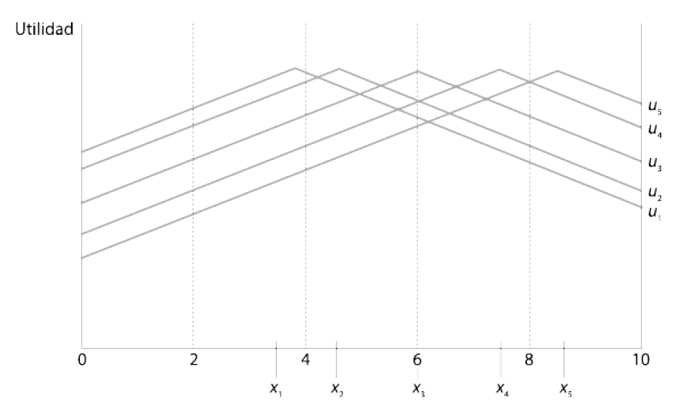

Preferencias a lo largo de una linea

## El rol del mediano (cont.)

- Las cinco personas, $G={1,2,3,4,5}$ tienen las preferencias mostradas en el gráfico anterior y representadas como $x={x_1,x_2,x_3,x_4,x_5}$.
- Cada individuo tiene un punto favorito $\longrightarrow$ “punto ideal”. Esa es la tasa de interés que el/ella prefiere en primer lugar. Por ejemplo, para el director 1:
  - $x_1 \succ x_2 \succ x_3 \succ x_4 \succ x_5$
- Las preferencias se “miden” a partir de la utilidad –i.e. la altura de la curva; cada una de las “campanas” es una función de utilidad para cada director.

## El rol del mediano (cont.)

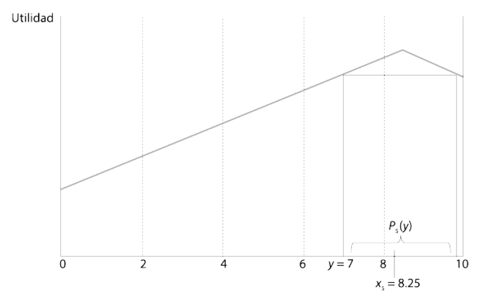

Conjuntos preferidos

## El rol del mediano (cont.)

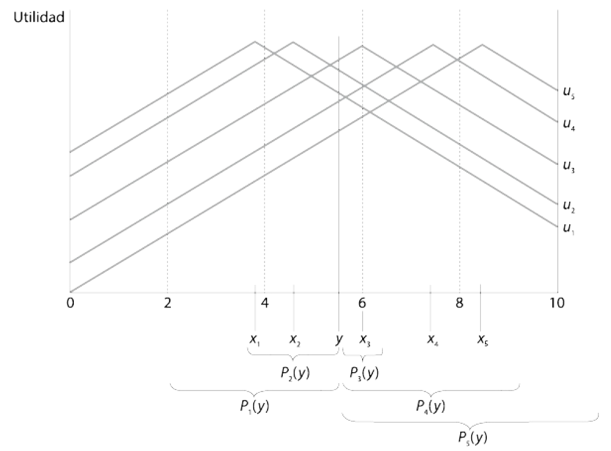

Superponiendo los conjuntos preferidos

## El rol del mediano (cont.)

- Ahora mostramos los “conjuntos preferidos a $y$” de todos los directores.Superposición:
  - $P_4(y)$ y $P_5(y)$ tienen puntos en común
  - $P_1(y)$ y $P_2(y)$ tienen puntos en común
  - Los individuos 3, 4 y 5 tienen conjuntos preferidos a $y$ que se superponen; forman una mayoría –3 contra 2, por lo que esa mayoría vence a una propuesta como $y$.
- Así, se tienen todas las mayorías posibles que vencen a $y$ dependiendo de donde este $y$ en la escala.Puede ahora mostrarse todas las coaliciones de mayorías posibles que vencen a $y$.

## El rol del mediano (cont.)

| Tamaño coalicion | Coalicion |
| --- | --- |
| 3 | (1,2,3) (1,2,4) (1,2,5) (1,3,4) (1,3,5) (1,4,5) (2,3,4) (2,3,5) (2,4,5) (3,4,5) |
| 4 | (1,2,3,4) (1,2,3,5) (1,2,4,5) (1,3,4,5) (2,3,4,5) |
| 5 | (1,2,3,4,5) |

## El rol del mediano (cont.)

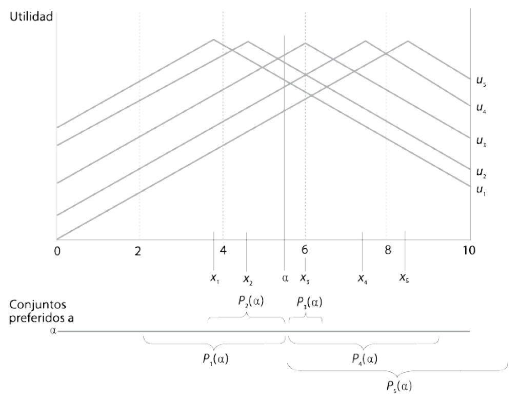

El rol del votante mediano